# Procesamiento 3

Maria Candelaria Dorta Delgado - Andres Felipe Beltran

5/11/2021

En este documento se presenta el flujo de trabajo utilizado para procesar los espectros compartidos en las carpetas `3_T 50` y `3 SST50`

Primero, creamos una lista con los nombres de los archivos contenidos en esta carpeta, para poder importarlos a `R`:

```r
nombres <- list.files(, pattern = 'CSV')
nombres
```

```
##   [1] "@A_50C_LF1_1.CSV"       "@A_50C_LF1_2.CSV"       "@A_50C_LF1_3.CSV"
##   [4] "@A_50C_LF2_1.CSV"       "@A_50C_LF2_2.CSV"       "@A_50C_LF2_3.CSV"
##   [7] "@A_50C_LF3_1.CSV"       "@A_50C_LF3_2.CSV"       "@A_50C_LF3_3.CSV"
##  [10] "@A_50C_LF4_1.CSV"       "@A_50C_LF4_2.CSV"       "@A_50C_LF4_3.CSV"
##  [13] "@A_50C_LF5_1.CSV"       "@A_50C_LF5_2.CSV"       "@A_50C_LF5_3.CSV"
##  [16] "@A_50C_UF1_1.CSV"       "@A_50C_UF1_2.CSV"       "@A_50C_UF1_3.CSV"
##  [19] "@A_50C_UF2_1.CSV"       "@A_50C_UF2_2.CSV"       "@A_50C_UF2_3.CSV"
##  [22] "@A_50C_UF3_1.CSV"       "@A_50C_UF3_2.CSV"       "@A_50C_UF3_3.CSV"
##  [25] "@A_50C_UF4_1.CSV"       "@A_50C_UF4_2.CSV"       "@A_50C_UF4_3.CSV"
##  [28] "@A_50C_UF5_1.CSV"       "@A_50C_UF5_2.CSV"       "@A_50C_UF5_3.CSV"
##  [31] "@A_SS_50C_LF1_1.CSV"    "@A_SS_50C_LF1_2.CSV"    "@A_SS_50C_LF1_3.CSV"
##  [34] "@A_SS_50C_LF2_1.CSV"    "@A_SS_50C_LF2_2.CSV"    "@A_SS_50C_LF2_3.CSV"
##  [37] "@A_SS_50C_LF3_1.CSV"    "@A_SS_50C_LF3_2.CSV"    "@A_SS_50C_LF3_3.CSV"
##  [40] "@A_SS_50C_LF4_1.CSV"    "@A_SS_50C_LF4_2.CSV"    "@A_SS_50C_LF4_3.CSV"
##  [43] "@A_SS_50C_LF5_1.CSV"    "@A_SS_50C_LF5_2.CSV"    "@A_SS_50C_LF5_3.CSV"
```

[output cut: 26 more lines]

Revisamos si los triplicados estan completos:

```r
(length(nombres)-1)/3
```

```
## [1] 40
```

Hasta el momento, hay un espectro repetido:

```r
nombres[46]
```

```
## [1] "@A_SS_50C_UF1_1(1).CSV"
```

Vamos a continuar sin este espectro por el momento:

```r
nombres <- nombres[-46]
```

Procedemos a utilizr la función `read.csv` para leer los archivos `.CSV` y crear objetos dentro de R que van a contener su información.

Ya que `nombres` es una lista, podemos utilizar la función de ciclo `lapply` para aplicar de manera iterativa la función `read.csv` a todos los elementos de la lista `nombres`, guardando el resultado de cada iteración en cada elemento de la lista `data`.

```r
data <- lapply(nombres, read.csv, header = FALSE)
```

`data` es un objeto de clase `list` que contiene en cada posición, un `data.frame` con la información de los `.csv`. Es decir, una columna con los números de onda, y otra con las absorbancias:

```r
str(data[[1]])
```

```
## 'data.frame':    1869 obs. of  2 variables:
##  $ V1: num  399 401 403 405 407 ...
##  $ V2: num  0.0129 0.0122 0.0122 0.0112 0.0106 ...
```

En este punto, podemos guardar la información de los números de onda en un objeto llamado `wavenumber`

```r
wavenumber <- data[[1]][,1]
```

En el chunk anterior guardamos lo que hay en la primera columna `[,1]` del primer elemento de `data`: `data[[1]]`

Ahora, podemos volver a aplicar la función `lapply`, en este caso a la lista `data` para extraer solo la segunda columna, que es la que nos interesa para construir nuestro data.frame para análisis quimiométrico.

```r
data2 <- lapply(data, '[', 2)
```

Al usar la función `lapply`, de nuevo creamos una lista. podemos convertir la lista `data2` en un `data.frame` mediante la función `as.data.frame`.

```r
data2 <- as.data.frame(data2)
dim(data2)
```

```
## [1] 1869  120
```

```r
names(data2) <- nombres
```

Ahora tenemos un `data.frame` con 1869 filas y 120 columnas, los triplicados de 40 muestras.

Ahora podemos proceder a crear la transpuesta de este data.frame utilizando la función `t()`:

```r
datat <- t(data2)
```

`datat` es un objeto de clase `matrix`, en cuyos `rownames` contiene los nombres de las muestras, como vienen en los nombres de los archivos `.CSV`.

Ahora, recuperamos la información almacenada en el objeto `wavenumber` para nombrar las columnas, o variables del objeto `datat`

```r
colnames(datat) <- wavenumber
```

Ahora, para encontrar los espectros a los cuales les vamos a calcular el promedio, utilizamos una matriz de búsqueda, conteniendo los niveles que diferencian las muestras, en este caso son:

- Zona de muestreo: `UF1` `UF2` `UF3` `UF4` `UF5` y `LF1` `LF2` `LF3` `LF4` `LF5`.
- tiempo de molienda: `A` y `B`.
- con o sin solución salina `SS` y .

```r
set.seed(0)

searchGrid <- expand.grid(Sampling = c('UF1',
                                       'UF2',
                                       'UF3',
                                       'UF4',
                                       'UF5',
                                       'LF1',
                                       'LF2',
                                       'LF3',
                                       'LF4',
                                       'LF5'),
                          millingTime = c('A',
                                          'B'),
                          brine = c('SS',
                                    ''))

# knitr::kable(searchGrid)
```

En la matriz `searchGrid` tenemos un total de 40 combinaciones para los nombres de las muestras, según las distintas variaciones de los tratamientos.

Vamos a utilizar esta matriz, para buscar entre todos los nombres de todos los espectros, y encontrar los tres triplicados para cada variación del experimento:

Primero, vamos a crear un vector que va a contener los nuevos nombres que identifican cada variación del experimento:

```r
rownames.prom <- character(40)
```

Luego, mediante un ciclo `for` podemos guardar en cada posición de `rownames.prom` la unión de las tres variables para cada experimento:

```r
for(i in 1:40){

  rownames.prom[i] <- paste(searchGrid[i,1],
      searchGrid[i,2],
      searchGrid[i,3])
}
rownames.prom
```

```
##  [1] "UF1 A SS" "UF2 A SS" "UF3 A SS" "UF4 A SS" "UF5 A SS" "LF1 A SS"
##  [7] "LF2 A SS" "LF3 A SS" "LF4 A SS" "LF5 A SS" "UF1 B SS" "UF2 B SS"
## [13] "UF3 B SS" "UF4 B SS" "UF5 B SS" "LF1 B SS" "LF2 B SS" "LF3 B SS"
## [19] "LF4 B SS" "LF5 B SS" "UF1 A "   "UF2 A "   "UF3 A "   "UF4 A "
## [25] "UF5 A "   "LF1 A "   "LF2 A "   "LF3 A "   "LF4 A "   "LF5 A "
## [31] "UF1 B "   "UF2 B "   "UF3 B "   "UF4 B "   "UF5 B "   "LF1 B "
## [37] "LF2 B "   "LF3 B "   "LF4 B "   "LF5 B "
```

Ahora, creamos la matriz en la cual vamos a guardar los resultados el promedio de cada triplicado:

```r
prom <- matrix(,
               ncol = ncol(datat),
               nrow = nrow(datat)/3)
```

Ahora, vamos a crear una lista llamada `index`. En esta lista, vamos a guardar las 3 posiciones dentro de la lista `nombres` que van a coincidir con las expresiones regulares dictadas por `searchGrid` para cada variación del experimento.

Por ejemplo, para `UF1 A SS`, la posición correspondiente en la lista `index` va a contener 3 elementos que nos dicen las posiciones para los espectros `UF1 A SS 1`, `UF1 A SS 2`, y `UF1 A SS 3` dentro de los nombres de las filas de `datat`.

```r
index <- vector('list',40)
```

Ahora, vamos a utilizar una función de búsqueda, anidada con una función de comparación.

- `grepl` función de búsqueda que utiliza expresiones regulares (variables según la búsqueda) junto con caracteres (provenientes de `searchGrid`) como input
- `which` función de comparación que nos dice si se cumple o no una condición, pasa como argumento el output de `grepl` que nos dice si sí o no coincide el elemento en cuestión con el criterio de búsqueda.

```r
for(i in 1:40){

  index[[i]] <- c(
                  which(
                         grepl(
                                paste0('(?=.*',
                                      as.character(searchGrid[i,1]),
                                      ')(?=.*',
                                      as.character(searchGrid[i,2]),
                                      ')(?=.*',
                                       as.character(searchGrid[i,3]),
                                      ')'

                                       ),
                rownames(datat), perl = T              )

                       )
                  )
}
```

podemos confirmar los resultados antes de calcular. Por ejemplo, para la primera fila de `searchGrid` :

```r
searchGrid[1,]
```

```
##   Sampling millingTime brine
## 1      UF1           A    SS
```

Ya tenemos ubicados los espectros que corresponden a esta combinación:

```r
index[[1]]
```

```
## [1] 46 47 48
```

confirmando en los nombres de las muestras de `datat`:

```r
rownames(datat)[index[[1]]]
```

```
## [1] "@A_SS_50C_UF1_1.CSV" "@A_SS_50C_UF1_2.CSV" "@A_SS_50C_UF1_3.CSV"
```

Corresponde a los tres triplicados de la muestra `UF1`, la cual tuvo un tiempo de molienda de 2 a 4 minutos, y una extracción con solución salina.

Podemos proceder a calcular los promedios:

```r
for(j in 1:length(colnames(datat))){

for(i in 1:40){

prom[i,j] <- mean(c(datat[index[[i]][1],j],
                    datat[index[[i]][2],j],
                    datat[index[[i]][3],j]
                      ) )
}
}

rownames(prom) <- rownames.prom
colnames(prom) <- wavenumber
```

Una vez calculados, podemos graficar los promedios:

Podemos diferenciar los espectros de las muestras a las cuales se les realizo la extracción con solución salina mediante una revisión

```r
NaCl <- vector('character', length(rownames(prom)))

for(i in 1:40){

 if(grepl('SS', rownames(prom)[i],perl =T)){NaCl[i]<- 'red'}
  else{NaCl[i]<- 'black'}

}


indexSS <- vector('logical',40)

 indexSS<-which(grepl('SS', rownames(prom),perl =T))
```

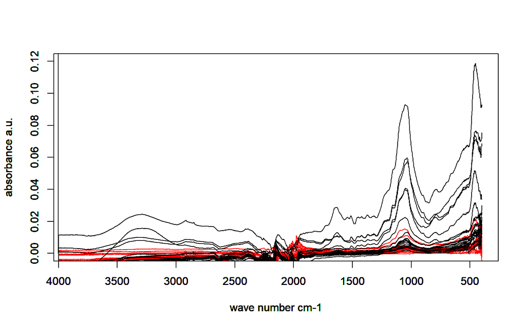

```r
for(i in 1:40){
  plot(wavenumber,
      prom[i,],
       xlab = 'wave number cm-1',
       ylab = 'absorbance a.u.',
       xlim = c(3900,400),
       ylim = c(0,0.12),
       type = 'l',
       col = NaCl[i])
  par(new = T)


}
```

Podemos seleccionar este rango , de 1700 a 400 $cm^{-1}$ creando un nuevo objeto para los promedios y para los números de ondaÑ

```r
colnames(prom)[c(1,676)]
```

```
## [1] "399.1989" "1700.935"
```

```r
Rango1 <- prom[,1:676]
wn.Rango1 <- wavenumber[1:676]
```

Para eliminar la variabilidad por ruido instrumental, podemos calcular y restar la línea base para cada uno de los promedios, utilizando el método `rubberband` disponible en el paquete de R `hyperSpec`, desarrollado para quimiometría aplicada a imágenes hiper-espectrales.

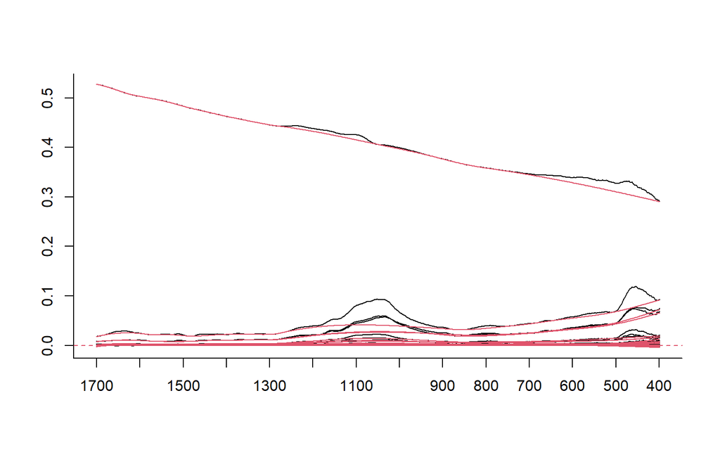

```r
library(hyperSpec)
spc <- new('hyperSpec', spc = Rango1, wavelength = wn.Rango1)
bend <- 0.1 * wl.eval (spc, function (x) x^6+x^5+x^4+x^3+x^2, normalize.wl=normalize01)

bl <- spc.rubberband (spc+bend, noise = 1e-4, df=20)-bend
suma <- spc+bend
spc3 <- spc - bl

plot(spc, wl.reverse = TRUE)
plot(bl, add=TRUE, col=2,wl.reverse = TRUE)
```

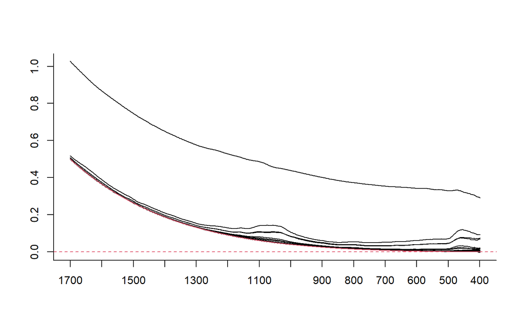

```r
plot(suma,wl.reverse = TRUE)
plot(bend, add=TRUE, col=2,wl.reverse = TRUE)
```

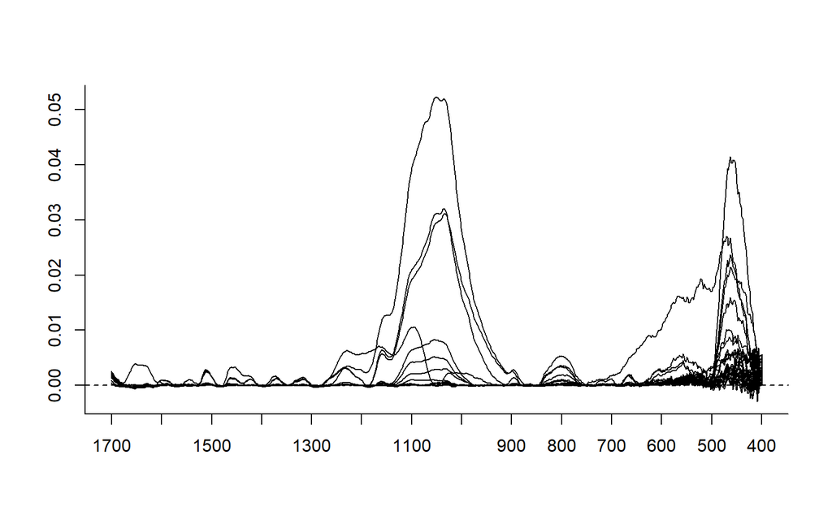

```r
plot(spc3,wl.reverse = TRUE)
```

```r
corregido <- as.data.frame(spc3[1:40])
corregido2 <- as.data.frame(corregido[,1])
```

En el procedimiento de corrección de línea base, observamos que uno de los espectros promedio tiene una deriva instrumental mucho más notoria que los demás, podemos preguntarle a R cual de los espectros presenta estos valores de absorbancia tan altos:

```r
which(prom[,1]>0.2)
```

```
## UF3 A
##     23
```

Sabiendo que es el elemento en la lista de promedios número 23, podemos preguntar a `index` a partir de que espectros se calculó el promedio, y graficar los tres para ver si los tres presentan el mismo comportamiento.

```r
index[[23]]
```

```
## [1] 22 23 24 52 53 54
```

```r
rownames(prom)[23]
```

```
## [1] "UF3 A "
```

```r
rownames(datat)[c(22,23,24)]
```

```
## [1] "@A_50C_UF3_1.CSV" "@A_50C_UF3_2.CSV" "@A_50C_UF3_3.CSV"
```

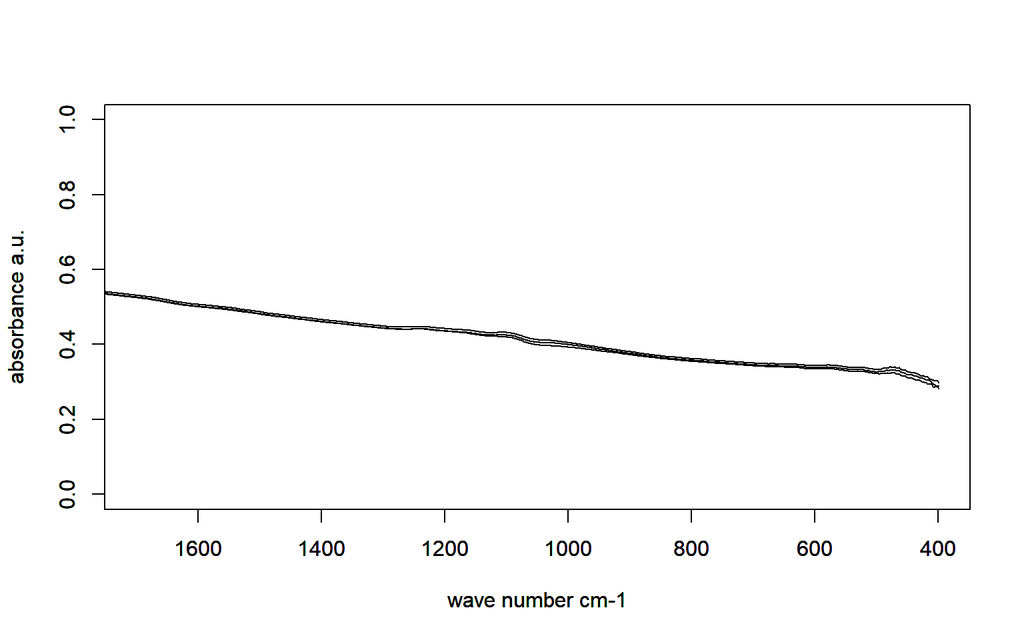

```r
for(i in 1:3){
  plot(wavenumber,
       datat[index[[23]][i],],
        xlab = 'wave number cm-1',
       ylab = 'absorbance a.u.',
       xlim = c(1700,400),
       ylim = c(0,1),
       type = 'l')
  par(new = T)




}
```

Con esto podemos confirmar que la desviación por deriva instrumental no se debe a una de las replicas, si no a la muestra `UF3 A`. A pesar de que con el tratamiento de corrección de línea base se elimina este problema, es importante confirmar cual es la muestra que presenta esta deriva.

Podemos graficar los espectros corregidos para este experimento:

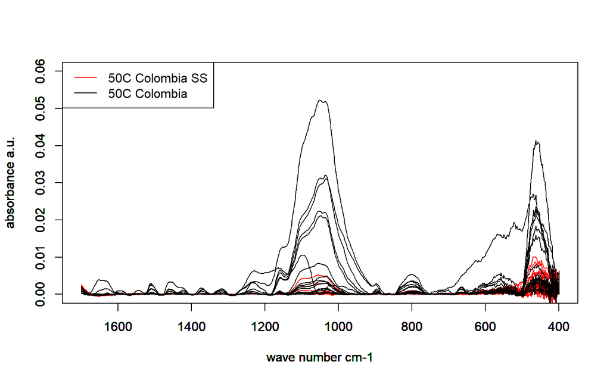

```r
for(i in 1:length(rownames(corregido2))){
  plot(wn.Rango1,
       corregido2[i,],
       xlab = 'wave number cm-1',
       ylab = 'absorbance a.u.',
       xlim = c(1700,400),
       ylim = c(0,0.06),
       type = 'l',
       col = NaCl[i])
  par(new = T)


}
legend('topleft',
       c('50C Colombia SS','50C Colombia'),
       col = c('red','black'),
       lty = 1)
```

# Derivatización de espectros

```r
library(prospectr)
```

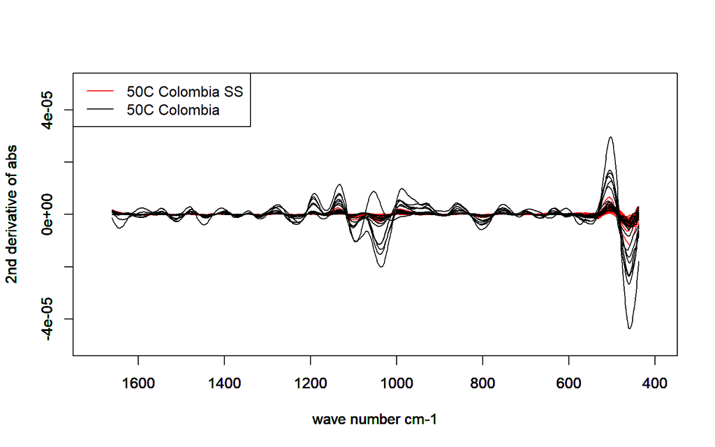

```r
w2 <- 40
sg <- matrix(ncol = ncol(corregido2)-w2, nrow= nrow(corregido2))
sg <- as.data.frame(sg)
# for (i in 1:31){
sg<- savitzkyGolay(X = corregido2
                        ,m = 2,
                        p = 3,
                        w = w2+1,
                        delta.wav=2)
# }
# colnames(sg) <- colnames( savitzkyGolay(X = corregido2[1,]
#                         ,m = 2,
#                         p = 3,
#                         w = w2+1,
#                         delta.wav=2))
rownames(sg) <- rownames(corregido2)
# win.graph()
for(i in 1:length(rownames(sg))){

  plot(as.numeric(colnames(sg)),
       sg[i,],
       xlab = 'wave number cm-1',
       ylab = '2nd derivative of abs',
       xlim = c(1700,400),
        ylim = c(-5e-05,5e-05),
       type = 'l',
       col = NaCl[i])
  par(new = T)


}
legend('topleft',
       c('50C Colombia SS','50C Colombia'),
       col = c('red','black'),
       lty = 1)
```

# Análisis exploratorio

## HCA

```r
df <- sg
library(factoextra)
```

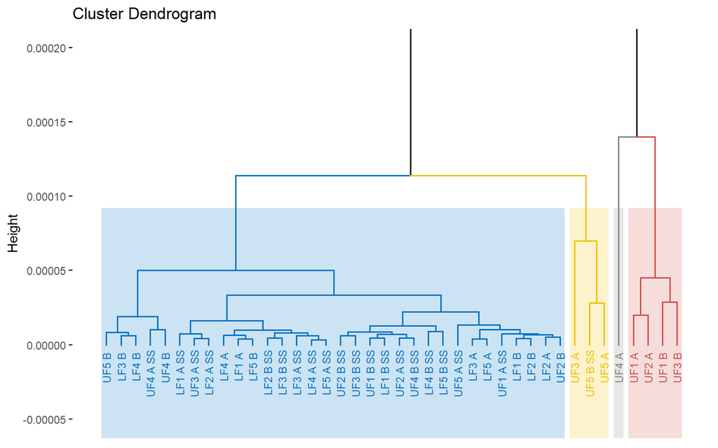

```r
res.hk <-hkmeans(df,
                 4,
                 hc.metric =  'minkowski')

fviz_dend(res.hk, cex = 0.6, palette = "jco",
          rect = TRUE, rect_border = "jco", rect_fill = TRUE, ylim = c(-5e-05,2e-04))
```

```r
pca.bl.sg <- prcomp(sg, scale =T, center = T)
vp.bl.sg <- (pca.bl.sg$sdev)^2
varianza.bl.sg <- round(vp.bl.sg/sum(vp.bl.sg)*100, 2)
varianza.bl.sg
```

```
##  [1] 65.60 12.99 10.53  3.43  1.93  1.65  1.07  0.74  0.39  0.34  0.29  0.22
## [13]  0.17  0.15  0.11  0.07  0.06  0.04  0.04  0.03  0.03  0.02  0.02  0.02
## [25]  0.01  0.01  0.01  0.01  0.01  0.01  0.01  0.01  0.00  0.00  0.00  0.00
## [37]  0.00  0.00  0.00  0.00
```

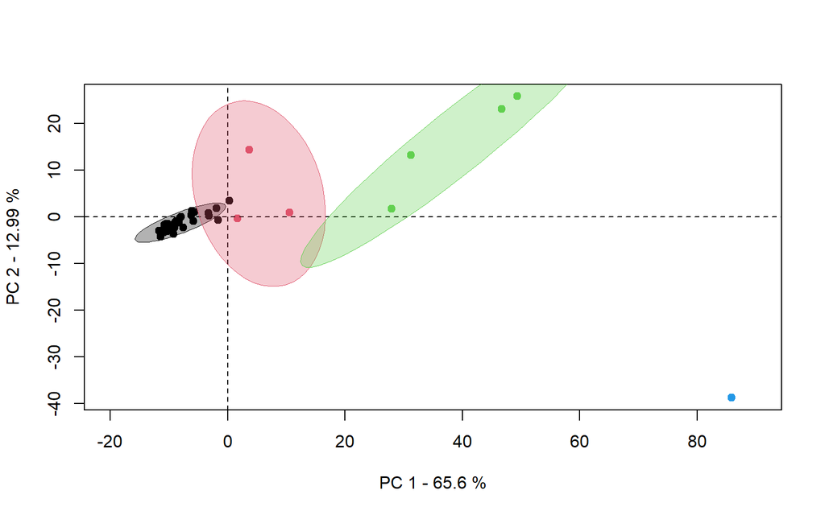

```r
coord.bl.sg <- pca.bl.sg$x

plot(coord.bl.sg[,1],
     coord.bl.sg[,2],
     pch = 19,
     xlab = paste('PC 1 -',as.character(varianza.bl.sg[1]), '%'),
     ylab = paste('PC 2 -',as.character(varianza.bl.sg[2]), '%'),
     col = res.hk$cluster,
     xlim = c(-20,90)
     )
abline(h = 0, v= 0, lty = 2)

x<- coord.bl.sg[,1]
y<- coord.bl.sg[,2]
z<- coord.bl.sg[,3]

x1<- x[res.hk$cluster == 1]
y1<- y[res.hk$cluster == 1]
z1<- z[res.hk$cluster == 1]

library(car)
ellipse(c(mean(x1),mean(y1)),
        cov(cbind(x1,y1)),
        radius= sqrt(qchisq(.95, df =2)),
        col=1,
        center.pch=FALSE,
        add=TRUE,
        # levels=0.95,
        fill=TRUE,
        lwd=0.8,

)

x2<- x[res.hk$cluster == 2]
y2<- y[res.hk$cluster == 2]
z2<- z[res.hk$cluster == 2]

ellipse(c(mean(x2),mean(y2)),
        cov(cbind(x2,y2)),
        radius= sqrt(qchisq(.95, df =2)),
        col=2,
        center.pch=FALSE,
        add=TRUE,
        # levels=0.95,
        fill=TRUE,
        lwd=0.8,

)

x3<- x[res.hk$cluster == 3]
y3<- y[res.hk$cluster == 3]
z3<- z[res.hk$cluster == 3]

ellipse(c(mean(x3),mean(y3)),
        cov(cbind(x3,y3)),
        radius= sqrt(qchisq(.95, df =2)),
        col=3,
        center.pch=FALSE,
        add=TRUE,
        # levels=0.95,
        fill=TRUE,
        lwd=0.8,

)
```

```r
# text(coord.bl.sg[,1],
#      coord.bl.sg[,2],
#      rownames(coord.bl.sg),
#      pos = 4,
#      cex = 0.5)
```

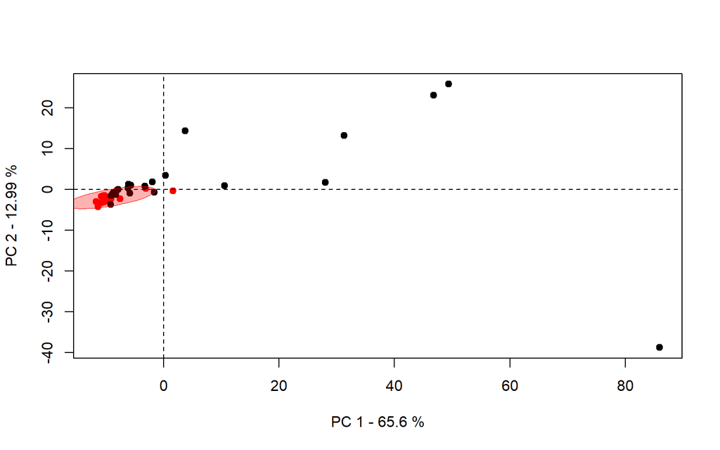

```r
x  <- coord.bl.sg[,1]
y  <- coord.bl.sg[,2]
z  <- coord.bl.sg[,3]
x1 <- x[NaCl=='red']
y1 <- y[NaCl=='red']
z1 <- z[NaCl=='red']
x2 <- x[NaCl=='black']
y2 <- y[NaCl=='black']
z2 <- z[NaCl=='black']

plot(coord.bl.sg[,1],
     coord.bl.sg[,2],
     pch = 19,
     xlab = paste('PC 1 -',as.character(varianza.bl.sg[1]), '%'),
     ylab = paste('PC 2 -',as.character(varianza.bl.sg[2]), '%'),
     col = NaCl
     )
abline(h = 0, v= 0, lty = 2)
library(car)
ellipse(c(mean(x1),mean(y1)),
        cov(cbind(x1,y1)),
        radius= sqrt(qchisq(.95, df =2)),
        col="red",
        center.pch=FALSE,
        add=TRUE,
        # levels=0.95,
        fill=TRUE,
        lwd=0.8,

)
```

```r
# ellipse(c(mean(x2),mean(y2)),
#         cov(cbind(x2,y2)),
#         radius= sqrt(qnorm(.95)),
#         col="black",
#         center.pch=FALSE,
#         add=TRUE,
#         # levels=0.95,
#         fill=TRUE,
#         lwd=0.8,
#
# )
```

```r
library(mdatools)
mdaPCA <-pca(corregido2, 5, center = TRUE, scale = TRUE)
summary(mdaPCA)
```

```
##
## Summary for PCA model (class pca)
## Type of limits: ddmoments
## Alpha: 0.05
## Gamma: 0.01
##
##        Eigenvals Expvar Cumexpvar Nq Nh
## Comp 1   390.761  57.80     57.80  1  1
## Comp 2   140.167  20.73     78.54  1  1
## Comp 3    48.271   7.14     85.68  3  1
## Comp 4    32.257   4.77     90.45  6  1
## Comp 5    12.548   1.86     92.31  5  1
```

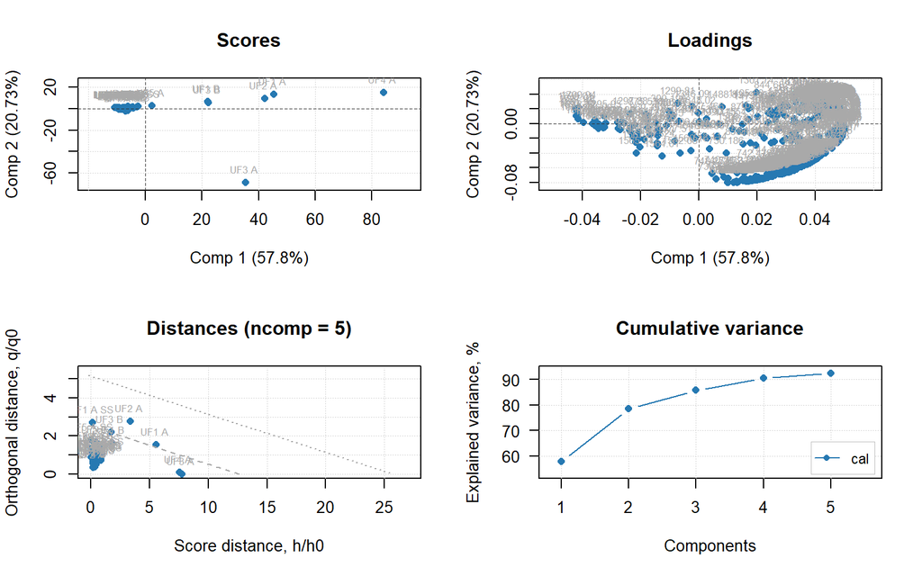

```r
plot(mdaPCA, show.labels = T)
```

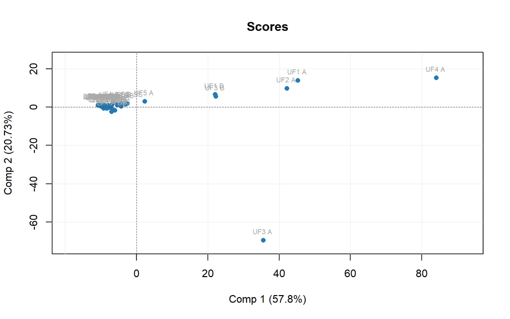

```r
# win.graph()
plotScores(mdaPCA$res$cal, show.labels = TRUE)
```

Ya que mediante PCA para estas muestras en específico, no se obserban agrupamientos notorios, podemos exportar estos resultados y compararlos con los resultados de los experimentos anteriores:

```r
write.table(prom, 'SSexp.txt' , sep = '\t')
```